# Iraq Displacement Crisis, 2014 to the Present

Sun-joo Lee

December 11, 2017

# Humanitarian Crisis in Iraq

The humanitarian crisis in Iraq has raged on since the ISIS insurgency in 2014, and is expected to continue until the country stabilizes. Millions of people remain displaced for years and thousands are searching for new homes abroad. However, international assistance and intervention remains intermittent; international funding for the crisis lags behind at about half of the requirements, and processing of refugee applications remains very slow. This brief report will represent the some of the key aspects of the humanitarian crisis in several graphs.

# Yearly Trends by Governorate of Internally Displaced People

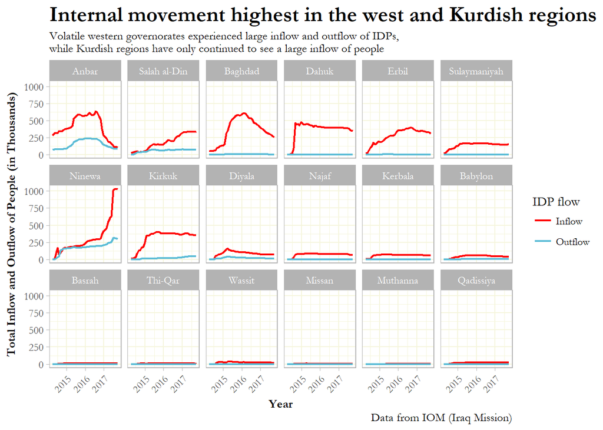

# Number of IDPs by Governorate

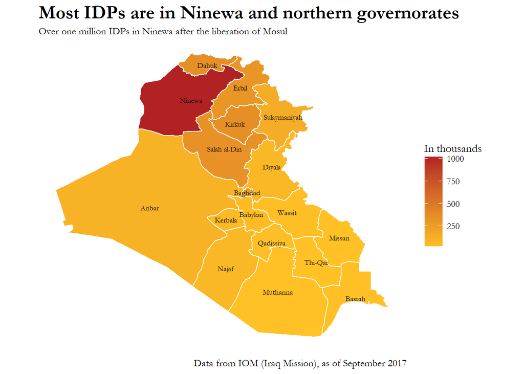

Ninewa governorate, where Mosul (the former capital of the Iraqi branch of ISIS) is located, currently has over a million IDPs. This has been the case since Mosul’s liberation in mid-2017. Baghdad, Kirkuk, Salah al-Din and the Kurdish governorates of Dahuk and Erbil have hosted a large number of IDPs throughout the crisis and continues to do so to the present.

# IDPs’ Types of Residence

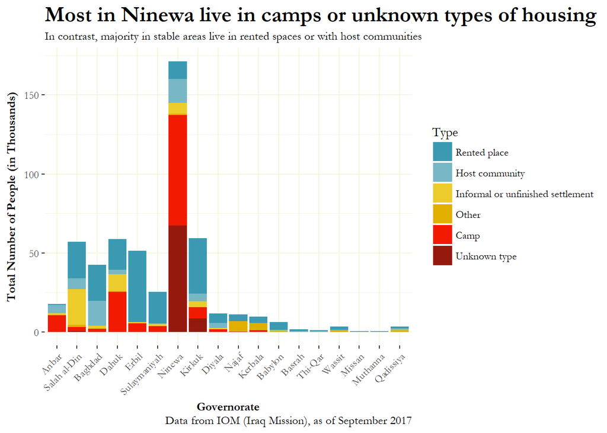

IDPs live in different types of residences, depending on their situation. The overwhelming majority of the newly displaced people in Ninewa governorate live in camps or in an unknown housing type. Nearby Dahuk also has a sizeable camp population. In many of the more stable governorates, such as Erbil, Kirkuk, and Sulaymaniyah, IDPs live in rented homes or with host communities.

# The Geographical Spread of IDPs

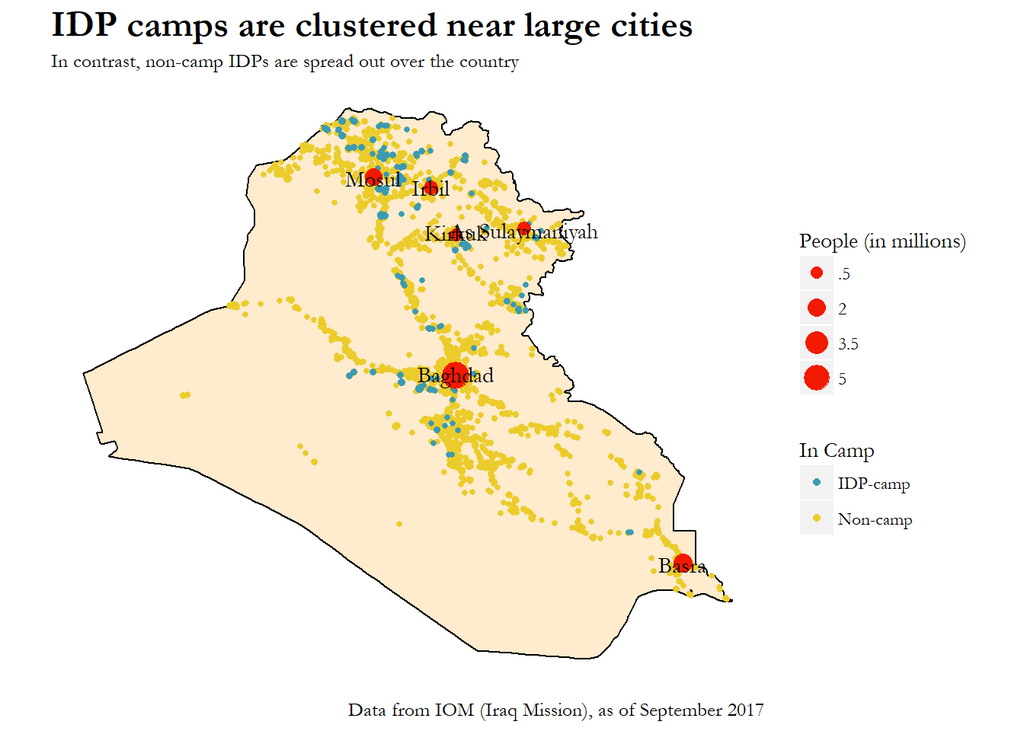

The yellow and blue dots show where IDPs reside, and cities of over half a million people are depicted in red. Non-camp IDPs are spread out over the country, while camps are near (but not usually in) large cities.

# Population Density in the Camps

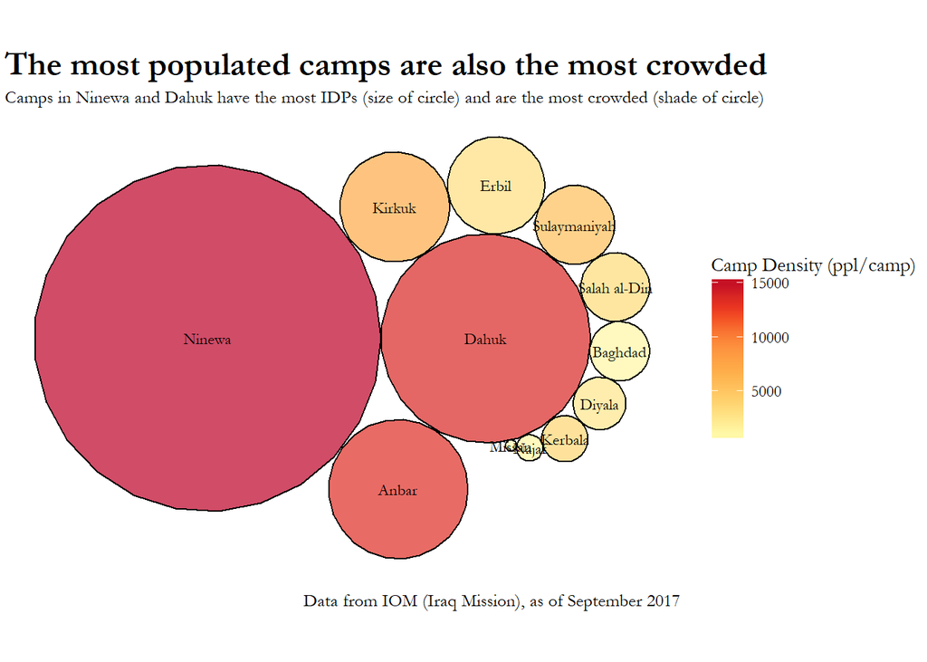

Conditions in IDP camps can vary greatly. Places with the greatest number of IDPs living in camps also tend to have the densest camps. Again, Ninewa has the largest number of people living in camps, with the average density at fifteen-thousand people per camp. Dahuk and Anbar also have a sizeable camp population, with over ten-thousand people per camp. Other governorates have a much smaller number of people in camps, which tend to be much less crowded.

# Humanitarian Funding in Iraq

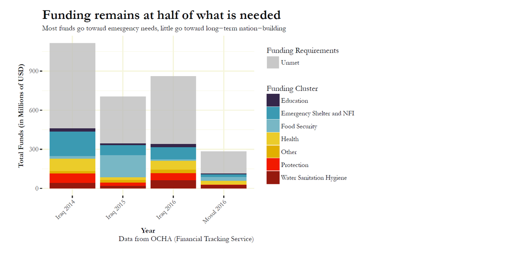

International funding remained at about half of the needs over the years. Much of the funds go toward emergency needs, such as shelter and non-food items, every year. A steady stream of funds also go to health, protection, and sanitation each year. Unfortunately, education remains underfunded.

# From IDP to Returnee

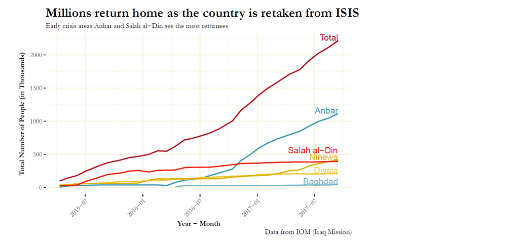

As parts of Iraq are liberated from ISIS control and are stablized, many IDPs are returning home. A small number of people began to return home as early as mid-2015, while the pace increased after mid-2016. Most of the current returnees are heading to Abar, which is where most of the earlier displacement had happened in 2014-15.

# Iraqi Refugees Around the World

[figure not shown]

Over 250,000 of the 310,000 Iraqi refugees around the world reside in 10 key countries in Europe and the Middle East. Germany and Turkey, in particular, host an increasingly large number of Iraqi refugees. In contrast, world powers that are further away from the crisis host comparitively fewer refugees; the US, UK, and Canada together host only 12,000 as of 2016.